# 10: Application 2

Rohit Koonireddy

2022-11-15

# Application 2: Neural Networks and Hyperparameter Tuning

The goal of this application is to put the basics of Neural Networks (NNs) that we covered over these weeks into practice. The task at hand is to predict the productivity of vegetation (`GPP_NT_VUT_REF`), using Multi Layer Perceptrons (MLPs). For this task we will be using the dataset `FLX_CH-Lae_FLUXNET2015_FULLSET_HH_2004-2014_1-3_CLEAN`, that has been preprocessed and cleaned to some extent.

## Introduction

### Learning goals

After this application you will be able to:

- Create training, validation and testing splits (70/15/15)
- Center and scale your data features (pre-processing) based on training statistics
- Use the validation set for hyper-parameter tuning and model selection (note that in many cases, those are synonims)
- Build and train a MLP NN for regression tasks, with 1 and 2 hidden layers
- Search best configuration over the number of neurons

### Key points to keep in mind

- To train a statistical model using machine learning, we split our data into training, validation and testing sets. If we do not have enough data, we can use $k$-fold cross-validation schemes to replace the validation set, and, in some extreme cases, the test set as well.
- Test data is set aside at the initial split and never ever used during model training nor hyperparameter and model selection. It is only used when we want to assess how well a model generalizes to previously unseen data, and only for that.
- Validation data is used to monitor the loss during model training. The training loss will often decrease no matter what, as NNs are very powerful (universal) approximators. The validation set mimics a held out set (i.e., it mimics a test set) to see how the different configurations of our model generalize over some held-out data. Held-out, means not used to optimize model parameters (remember the difference between *parameter* and *hyperparameter*).
- Machine learning algorithms have hyperparameters. These are parameters that are set by the user rather than learned during training. An example is the learning rate in gradient descent. In the case of Artificial Neural Networks, this can be the number of nodes per hidden layer, or the number of hidden layers.
- Loss is a measure of how well our trained model fits training labels. Loss is high when predictions are poor. Loss is low when predictions are good.
- Model training minimizes the loss. In other words, it maximizes the agreement between predicted and observed values. The loss over the validation set is a passive (i.e., not directly optimized) measure of agreement over the held out set. We’ve seen that for regression, most common losses are accuracy (or error) measures, while for classification it might be more involved. No worries, here we do regression.
- There are several ways to measure loss. RMSE (Root Mean Squared Error) or MSE are such measures. It is used in regression problem, as it is smooth and differentiable everywhere. Another common measure of error (which cannot be used as optimisation objective function) is the MAE or mean absolute error.
- To tune a model, you can set hyperparameters that determine model structure or calibrate the coefficients.

## Application

### Problem Statement

For this application we can use the reduced and cleaned dataset with half-hourly data `FLX_CH-Lae_FLUXNET2015_FULLSET_HH_2004-2014_1-3_CLEAN.csv`. The task is to predict the *productivity of vegetation (GPP)*, using all the other features as predictor variables.

`GPP_NT_VUT_REF` from the dataset is the target variable and rest of the columns can be used as the input predictor variables.

- Use these inputs for a neural network with just one hidden layer.
- Check training, validation and test metrics to understand their agreement and see whether the split is appropriate for the task.
- Use the validation set to optimize hyper-parameters such as number of neurons, number of layers, choice of activation function etc…
- Use MSE loss as a metric for monitoring the performance, plot the MSE loss as a function of the number of epochs.
- Plot the MSE as a function of the hyperparameters used.
- And some more specific steps.
- At the end of this application, there are some pointers that can be further explored but are not part of the application requirements.

### Data preparation

```r
## Loading the required libraries
library(reticulate)
#use_condaenv('r-reticulate')
library(keras)
library(tensorflow)
library(caret)
library(tidyverse)
library(recipes)
```

```r
### Read in the .csv file as a dataframe
data_bird <- read.csv2("data/FLX_CH-Lae_FLUXNET2015_FULLSET_HH_2004-2014_1-3_CLEAN.csv",sep = ",",dec = ".")

### Things to check when preprocessing
# Look at the structure and shape of the data (print it out using str())
str(data_bird)
```

```
## 'data.frame':    192864 obs. of  20 variables:
##  $ TIMESTAMP_START: chr  "2004-01-01T00:00:00Z" "2004-01-01T00:30:00Z" "2004-01-01T01:00:00Z" "2004-01-01T01:30:00Z" ...
##  $ TIMESTAMP_END  : chr  "2004-01-01T00:30:00Z" "2004-01-01T01:00:00Z" "2004-01-01T01:30:00Z" "2004-01-01T02:00:00Z" ...
##  $ TA_F           : num  -2.22 -2.25 -2.28 -2.5 -2.72 ...
##  $ SW_IN_F        : num  0 0 0 0 0 0 0 0 0 0 ...
##  $ LW_IN_F        : num  304 304 281 281 281 ...
##  $ VPD_F          : num  0.562 0.56 0.558 0.565 0.571 0.577 0.584 0.59 0.596 0.606 ...
##  $ PA_F           : num  93.3 93.3 93.3 93.3 93.3 ...
##  $ P_F            : num  0.014 0.014 0 0 0 0 0 0 0 0 ...
##  $ WS_F           : num  2.2 2.13 2.06 1.96 1.85 ...
##  $ CO2_F_MDS      : num  NA NA NA NA NA NA NA NA NA NA ...
##  $ PPFD_IN        : num  NA NA NA NA NA NA NA NA NA NA ...
##  $ GPP_NT_VUT_REF : num  NA NA NA NA NA NA NA NA NA NA ...
##  $ SWC_F_MDS_1    : num  NA NA NA NA NA NA NA NA NA NA ...
##  $ SWC_F_MDS_2    : num  NA NA NA NA NA NA NA NA NA NA ...
##  $ SWC_F_MDS_3    : num  NA NA NA NA NA NA NA NA NA NA ...
##  $ WS             : num  NA NA NA NA NA NA NA NA NA NA ...
##  $ WD             : num  NA NA NA NA NA NA NA NA NA NA ...
##  $ RH             : num  NA NA NA NA NA NA NA NA NA NA ...
##  $ NIGHT          : int  1 1 1 1 1 1 1 1 1 1 ...
##  $ NEE_VUT_REF_QC : int  3 3 3 3 3 3 3 3 3 3 ...
```

```r
# Convert time-stamp columns from strings to datetime object using as.POSIXct()
data_bird$TIMESTAMP_START <- as.POSIXct(data_bird$TIMESTAMP_START, format = "%Y-%m-%dT%H:%M:%S")
data_bird$TIMESTAMP_END <- as.POSIXct(data_bird$TIMESTAMP_END, format = "%Y-%m-%dT%H:%M:%S")

# As we treat the observations as IID, we don't really need the time-stamp values as a feature variable, but we still retain them as they will be used for some time series plots later.

### Check the structure of your data again (print it out using str())
str(data_bird)
```

```
## 'data.frame':    192864 obs. of  20 variables:
##  $ TIMESTAMP_START: POSIXct, format: "2004-01-01 00:00:00" "2004-01-01 00:30:00" ...
##  $ TIMESTAMP_END  : POSIXct, format: "2004-01-01 00:30:00" "2004-01-01 01:00:00" ...
##  $ TA_F           : num  -2.22 -2.25 -2.28 -2.5 -2.72 ...
##  $ SW_IN_F        : num  0 0 0 0 0 0 0 0 0 0 ...
##  $ LW_IN_F        : num  304 304 281 281 281 ...
##  $ VPD_F          : num  0.562 0.56 0.558 0.565 0.571 0.577 0.584 0.59 0.596 0.606 ...
##  $ PA_F           : num  93.3 93.3 93.3 93.3 93.3 ...
##  $ P_F            : num  0.014 0.014 0 0 0 0 0 0 0 0 ...
##  $ WS_F           : num  2.2 2.13 2.06 1.96 1.85 ...
##  $ CO2_F_MDS      : num  NA NA NA NA NA NA NA NA NA NA ...
##  $ PPFD_IN        : num  NA NA NA NA NA NA NA NA NA NA ...
##  $ GPP_NT_VUT_REF : num  NA NA NA NA NA NA NA NA NA NA ...
##  $ SWC_F_MDS_1    : num  NA NA NA NA NA NA NA NA NA NA ...
##  $ SWC_F_MDS_2    : num  NA NA NA NA NA NA NA NA NA NA ...
##  $ SWC_F_MDS_3    : num  NA NA NA NA NA NA NA NA NA NA ...
##  $ WS             : num  NA NA NA NA NA NA NA NA NA NA ...
##  $ WD             : num  NA NA NA NA NA NA NA NA NA NA ...
##  $ RH             : num  NA NA NA NA NA NA NA NA NA NA ...
##  $ NIGHT          : int  1 1 1 1 1 1 1 1 1 1 ...
##  $ NEE_VUT_REF_QC : int  3 3 3 3 3 3 3 3 3 3 ...
```

```r
head(data_bird)
```

```
##       TIMESTAMP_START       TIMESTAMP_END   TA_F SW_IN_F LW_IN_F VPD_F   PA_F
## 1 2004-01-01 00:00:00 2004-01-01 00:30:00 -2.221       0 304.336 0.562 93.337
## 2 2004-01-01 00:30:00 2004-01-01 01:00:00 -2.250       0 304.336 0.560 93.325
## 3 2004-01-01 01:00:00 2004-01-01 01:30:00 -2.280       0 280.515 0.558 93.313
## 4 2004-01-01 01:30:00 2004-01-01 02:00:00 -2.501       0 280.515 0.565 93.295
## 5 2004-01-01 02:00:00 2004-01-01 02:30:00 -2.723       0 280.515 0.571 93.276
## 6 2004-01-01 02:30:00 2004-01-01 03:00:00 -2.945       0 280.515 0.577 93.258
##     P_F  WS_F CO2_F_MDS PPFD_IN GPP_NT_VUT_REF SWC_F_MDS_1 SWC_F_MDS_2
## 1 0.014 2.200        NA      NA             NA          NA          NA
## 2 0.014 2.131        NA      NA             NA          NA          NA
## 3 0.000 2.062        NA      NA             NA          NA          NA
## 4 0.000 1.957        NA      NA             NA          NA          NA
## 5 0.000 1.853        NA      NA             NA          NA          NA
## 6 0.000 1.748        NA      NA             NA          NA          NA
##   SWC_F_MDS_3 WS WD RH NIGHT NEE_VUT_REF_QC
## 1          NA NA NA NA     1              3
## 2          NA NA NA NA     1              3
## 3          NA NA NA NA     1              3
## 4          NA NA NA NA     1              3
## 5          NA NA NA NA     1              3
## 6          NA NA NA NA     1              3
```

We now remove all the rows where the *target* variable is NA. As the target `GPP_NT_VUT_REF` is missing, we cannot learn or test against this data, so we remove all the rows where the target variable is missing. If we are happy with the model, we could go back to these missing rows data and use our MLP to impute (i.e., interpolate) missing `GPP_NT_VUT_REF` values. The variables `NIGHT`, `NEE_VUT_REF_QC` do not carry any additional information for this application, and we can drop them from our dataframe.

```r
## Drop rows with NAs for GPP_NT_VUT_REF, and discard the columns NEE_VUT_REF_QC and NIGHT
data_bird <- data_bird[!is.na(data_bird$GPP_NT_VUT_REF), ]
data_bird <- data_bird[, !(names(data_bird) %in% c("NEE_VUT_REF_QC", "NIGHT"))]

## Print the dimensionality of the data frame now to check how many rows have been deleted, and the num of columns remaining
cat("Number of rows:", nrow(data_bird), "\n")
```

```
## Number of rows: 176132
```

```r
cat("Number of columns:", ncol(data_bird), "\n")
```

```
## Number of columns: 18
```

```r
## Print the summary() of your dataframe for some more information about your variables
summary(data_bird)
```

```
##  TIMESTAMP_START                 TIMESTAMP_END
##  Min.   :2004-03-31 11:00:00.0   Min.   :2004-03-31 11:30:00.00
##  1st Qu.:2007-02-04 11:52:30.0   1st Qu.:2007-02-04 12:22:30.00
##  Median :2009-10-01 17:15:00.0   Median :2009-10-01 17:45:00.00
##  Mean   :2009-09-26 02:34:05.7   Mean   :2009-09-26 03:04:06.01
##  3rd Qu.:2012-05-19 19:37:30.0   3rd Qu.:2012-05-19 20:07:30.00
##  Max.   :2014-12-31 23:30:00.0   Max.   :2015-01-01 00:00:00.00
##  NA's   :20                      NA's   :20
##       TA_F            SW_IN_F            LW_IN_F          VPD_F
##  Min.   :-17.200   Min.   :   0.000   Min.   :135.4   Min.   : 0.000
##  1st Qu.:  1.520   1st Qu.:   0.000   1st Qu.:275.4   1st Qu.: 0.203
##  Median :  8.010   Median :   2.139   Median :310.5   Median : 1.737
##  Mean   :  7.808   Mean   : 138.904   Mean   :304.2   Mean   : 3.313
##  3rd Qu.: 13.850   3rd Qu.: 182.627   3rd Qu.:337.2   3rd Qu.: 4.877
##  Max.   : 31.820   Max.   :1074.410   Max.   :423.9   Max.   :34.391
##
##       PA_F            P_F              WS_F          CO2_F_MDS
##  Min.   :89.57   Min.   :0.0000   Min.   : 0.004   Min.   :210.8
##  1st Qu.:92.86   1st Qu.:0.0000   1st Qu.: 1.180   1st Qu.:370.7
##  Median :93.34   Median :0.0000   Median : 2.065   Median :386.5
##  Mean   :93.26   Mean   :0.0656   Mean   : 2.499   Mean   :395.9
##  3rd Qu.:93.75   3rd Qu.:0.0590   3rd Qu.: 3.366   3rd Qu.:401.6
##  Max.   :95.32   Max.   :3.5510   Max.   :13.249   Max.   :999.4
##
##     PPFD_IN         GPP_NT_VUT_REF      SWC_F_MDS_1     SWC_F_MDS_2
##  Min.   :   3.399   Min.   :-35.4686   Min.   : 7.70   Min.   : 6.532
##  1st Qu.:   4.114   1st Qu.: -0.3901   1st Qu.:18.46   1st Qu.:17.340
##  Median :   6.831   Median :  1.6599   Median :21.17   Median :22.050
##  Mean   : 281.226   Mean   :  4.8678   Mean   :21.47   Mean   :21.213
##  3rd Qu.: 341.000   3rd Qu.:  7.7467   3rd Qu.:25.03   3rd Qu.:24.690
##  Max.   :2170.000   Max.   : 61.1749   Max.   :32.74   Max.   :32.086
##  NA's   :5172                          NA's   :15112   NA's   :8344
##   SWC_F_MDS_3          WS               WD                RH
##  Min.   : 7.32   Min.   : 0.004   Min.   :  0.062   Min.   : 17.09
##  1st Qu.:18.61   1st Qu.: 1.174   1st Qu.:101.198   1st Qu.: 65.74
##  Median :21.55   Median : 2.065   Median :227.899   Median : 81.80
##  Mean   :21.24   Mean   : 2.502   Mean   :188.123   Mean   : 78.89
##  3rd Qu.:24.01   3rd Qu.: 3.377   3rd Qu.:259.823   3rd Qu.: 97.10
##  Max.   :31.79   Max.   :13.249   Max.   :359.987   Max.   :100.00
##  NA's   :8344    NA's   :4039     NA's   :3442      NA's   :6017
```

We see that there are still a few variables with NA values. Let’s see how many NAs each column has and what would be the number of rows in the resulting dataframe if we drop all rows with NAs

```r
## Compute how many rows have NA values for each column, and report the result for each column, print the result
# e.g.
# TIMESTAMP_START                 0
# TIMESTAMP_START0TIMESTAMP_END   0
# TA_F                            abc
# .
# .
# .
# RH                           xyz

na_counts <- colSums(is.na(data_bird))
print("Number of NA values for each column:")
```

```
## [1] "Number of NA values for each column:"
```

```r
print(na_counts)
```

```
## TIMESTAMP_START   TIMESTAMP_END            TA_F         SW_IN_F         LW_IN_F
##              20              20               0               0               0
##           VPD_F            PA_F             P_F            WS_F       CO2_F_MDS
##               0               0               0               0               0
##         PPFD_IN  GPP_NT_VUT_REF     SWC_F_MDS_1     SWC_F_MDS_2     SWC_F_MDS_3
##            5172               0           15112            8344            8344
##              WS              WD              RH
##            4039            3442            6017
```

```r
## Compute the rows we will be left with, if we drop all rows where even 1 column contains NA, print the result
rows_after_dropping_na <- nrow(data_bird[complete.cases(data_bird), ])
cat("Number of rows remaining after dropping rows with any NA values:", rows_after_dropping_na, "\n")
```

```
## Number of rows remaining after dropping rows with any NA values: 155451
```

The number of rows with NA values are not that large compared to the current size of the dataset. So we can afford to discard these rows without reducing the size of our dataset by much, and we still have enough data to carry out analysis.

*Sidenote:* It can happen in some cases that by doing so we lose a majority of our dataset, because each row has at least 1 column with NA. If the number of rows reduced significantly by this operation, we would use some data imputation technique to fill-in these NA values. But also note that by doing so, we are introducing some bias to our model, by the data imputation technique we choose. A common strategy is to either use models that can work also with missing values, or drop columns with many NAs, inpute others, and check what combinations provide good validation accuracy. This “preprocessing” step counts as *model selection*.

```r
## Drop all the rows with NAs
data_bird <- na.omit(data_bird)

## Create variables for reference
time_cols <- c("TIMESTAMP_START", "TIMESTAMP_END")
target_variable <- "GPP_NT_VUT_REF"
column_names <- colnames(data_bird)
## time stamp columns and the target variables are not used as predictors
predictors <- column_names[!column_names %in% c(target_variable, time_cols)]

## Print the dimensionality of the data frame after dropping rows
cat("Number of rows remaining after dropping rows with any NA values:", nrow(data_bird), "\n")
```

```
## Number of rows remaining after dropping rows with any NA values: 155451
```

```r
cat("Number of columns:", ncol(data_bird), "\n")
```

```
## Number of columns: 18
```

```r
column_names <- colnames(data_bird)
column_names
```

```
##  [1] "TIMESTAMP_START" "TIMESTAMP_END"   "TA_F"            "SW_IN_F"
##  [5] "LW_IN_F"         "VPD_F"           "PA_F"            "P_F"
##  [9] "WS_F"            "CO2_F_MDS"       "PPFD_IN"         "GPP_NT_VUT_REF"
## [13] "SWC_F_MDS_1"     "SWC_F_MDS_2"     "SWC_F_MDS_3"     "WS"
## [17] "WD"              "RH"
```

Next, we create indices to split the entire dataset into train, validation and test (70/15/15) splits.

The 70% of our data will be used to train the models. The rest 30% will be our held-out validation and test sets: the former to select best architecture and hyperparameters and the latter to evaluate the generalization performance of the model, as if we were to apply it to a new, unseen, dataset.

This dataset is actually a time series, so data in principle should be split into temporally disjoint learning sets. However, this is true if the main task is to develop *predictive* models, which extrapolate outside the training data domain. For instance, one would like to predict in the future `GPP` given other variables that might be simulated by weather models.

However, in this application, we rephrase the problem as *interpolating* in the training data: we want to fill missing values of our target variable, so we want to learn a model that generalises well over the training data domain. The interested person is encouraged to redo this application by splitting train, validation and test as disjoint learning sets. They are also encouraged to check the statistical distributions (eg scatterplot, histograms) of the different sets and see what happens!

To be fully honest, *interpolation* model reduces a lot of complications, while still being a crucial example for many real world applications!

Let’s plot the time series of our target, just because.

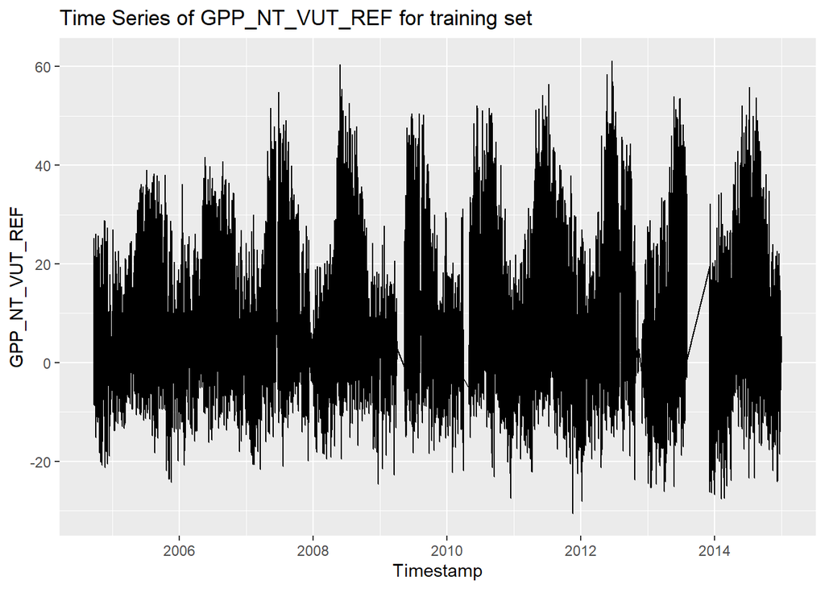

```r
# Set the seed for reproducibility
set.seed(123)

# Create indices for train, validation, and test sets (70/15/15)
n <- nrow(data_bird)
train_indices <- sample(1:n, 0.7 * n)
remaining_indices <- setdiff(1:n, train_indices)
validation_indices <- sample(remaining_indices, 0.5 * length(remaining_indices))
test_indices <- setdiff(remaining_indices, validation_indices)

# Create train, validation, and test sets
train_set <- data_bird[train_indices, ]
validation_set <- data_bird[validation_indices, ]
test_set <- data_bird[test_indices, ]

# Plot the time series of the target variable
library(ggplot2)

p_tr <- ggplot(train_set, aes(x = TIMESTAMP_START, y = GPP_NT_VUT_REF)) +
  geom_line() +
  labs(title = "Time Series of GPP_NT_VUT_REF for training set",
       x = "Timestamp",
       y = "GPP_NT_VUT_REF")

print(p_tr)
```

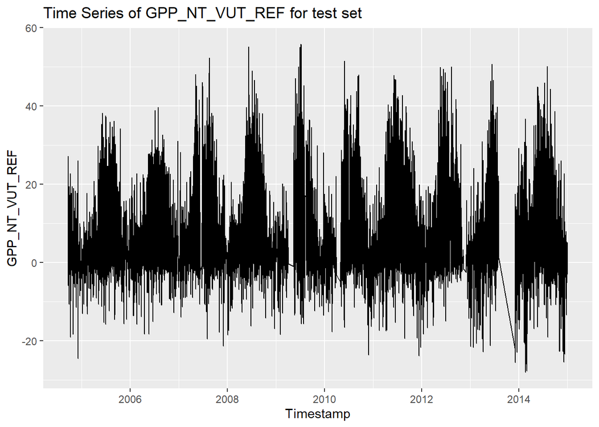

```r
t_tr <- ggplot(test_set, aes(x = TIMESTAMP_START, y = GPP_NT_VUT_REF)) +
  geom_line() +
  labs(title = "Time Series of GPP_NT_VUT_REF for test set",
       x = "Timestamp",
       y = "GPP_NT_VUT_REF")

print(t_tr)
```

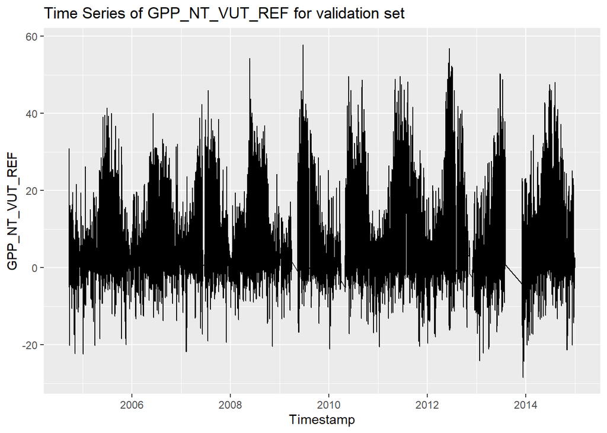

```r
v_tr <- ggplot(validation_set, aes(x = TIMESTAMP_START, y = GPP_NT_VUT_REF)) +
  geom_line() +
  labs(title = "Time Series of GPP_NT_VUT_REF for validation set",
       x = "Timestamp",
       y = "GPP_NT_VUT_REF")

print(v_tr)
```

```r
## Set seed for reproducibility
set.seed(123)

## First shuffle the dataset
shuffled_data_bird <- data_bird[sample(nrow(data_bird)), ]

## Get indices for train, validation, and test splits
n <- nrow(shuffled_data_bird)
train_indices <- sample(1:n, 0.7 * n)
remaining_indices <- setdiff(1:n, train_indices)
validation_indices <- sample(remaining_indices, 0.5 * length(remaining_indices))
test_indices <- setdiff(remaining_indices, validation_indices)

## Use the indices to get train, validation, and test splits
train_data <- shuffled_data_bird[train_indices, ]
validation_data <- shuffled_data_bird[validation_indices, ]
test_data <- shuffled_data_bird[test_indices, ]
```

Next we separate the target variable from the predictors.

```r
# Save time stamps for the test and train splits, as a separate data frame for time-series plots
trn_target <- train_data$GPP_NT_VUT_REF
trn_data <- train_data[, !(names(train_data) %in% c("GPP_NT_VUT_REF", "TIMESTAMP_START", "TIMESTAMP_END"))]

val_target <- validation_data$GPP_NT_VUT_REF
val_data <- validation_data[, !(names(validation_data) %in% c("GPP_NT_VUT_REF", "TIMESTAMP_START", "TIMESTAMP_END"))]

tst_target <- test_data$GPP_NT_VUT_REF
tst_data <- test_data[, !(names(test_data) %in% c("GPP_NT_VUT_REF", "TIMESTAMP_START", "TIMESTAMP_END"))]

# Separate the splits to get trn_data, trn_target; val_data, val_target; test_data and val_target. After this you should have 6 corresponding dataframes, one per learning set. Also drop the time stamp columns from the train data and test data as we treat the observations as IID. (we keep them for plots)
trn_timestamps <- train_data[, c("TIMESTAMP_START", "TIMESTAMP_END")]
tst_timestamps <- test_data[, c("TIMESTAMP_START", "TIMESTAMP_END")]
val_timestamps <- validation_data[, c("TIMESTAMP_START", "TIMESTAMP_END")]

## Print the head of tst_data to check the structure
head(tst_data)
```

```
##          TA_F SW_IN_F LW_IN_F  VPD_F   PA_F   P_F  WS_F CO2_F_MDS  PPFD_IN
## 128934 14.660   0.000 259.363 10.167 94.001 0.000 1.377   394.045    4.295
## 83451   4.682 535.306 298.816  0.836 93.540 0.149 4.113   479.371 1102.000
## 175984  1.561   0.000 332.214  0.027 92.189 0.430 1.188   466.538    4.143
## 34911  -9.720   0.000 249.768  0.263 91.964 0.069 2.725   381.804    3.714
## 62268  13.380  24.520 380.873  0.384 93.423 0.075 0.546   363.390   50.220
## 102881  6.892  49.785 303.782  0.806 93.240 0.000 1.597   388.908  106.300
##        SWC_F_MDS_1 SWC_F_MDS_2 SWC_F_MDS_3    WS      WD    RH
## 128934      16.660      15.190       17.61 1.377  85.906 39.08
## 83451       15.700      17.680       17.05 4.113 253.663 90.20
## 175984      26.151      28.453       22.29 1.188 251.872 99.60
## 34911       18.870      17.030       21.04 2.725 267.109 91.00
## 62268       13.660      15.600       15.97 0.546 235.800 97.50
## 102881      21.850      22.110       20.01 1.597 242.281 91.90
```

### Center and scale

Take care to extract the centering and scaling parameters from the training set and use them to center and scale your validation and test data!

If you use the entire data set to get the centering and scaling parameters, we actually use some information from the test data, which is something we generally do not have access to in real life. Thus doing so could result in *information leakage* from the test data into the training set, and we may get results more optimistic than our model’s predictions on actually unseend data. Follow the steps below to carry out centering and scaling in a proper way:

- Extract normalization parameters from *train* data for numeric predictors
- Normalize train data using these parameters
- Normalize test data using the parameters extracted from *train* data
- Generally we only normalize the numeric variables and not the factors

Plots the `summary()` of the different sets and compare statistcis.

```r
## Make use of preProcess() logic or any other function you wish, to scale and center each of the columns. Also store mean, sd manually and rescale sets is easy enough.

print("trn data")
summary(trn_data)
print("val data")
summary(val_data)
print("tst data")
summary(tst_data)
```

[output not shown]

Are all of the columns in the training, validation and test set centered perfectly with to the same mean of 0? Why?

Note that in some cases, we can also rescale the target variable. For instance, to make the distribution more “normal” like, or to range values from only positives to also negative (e.g., with a log transform). Those situations are to be understood by data exploration, and, in case of doubts, can also be seen as model selection steps. Just be sure to transform back to the original data scale the target, before computing the error!

```r
## Make use of preProcess() logic or any other function you wish to scale and center each of the columns.
## Also store mean, sd manually, and rescale sets is easy enough.

# Extract normalization parameters from train data for numeric predictors
scaling_parameters <- preProcess(trn_data, method = c("center", "scale"))

# Normalize train data using these parameters
trn_data_scaled <- predict(scaling_parameters, newdata = trn_data)

# Normalize validation data using the parameters extracted from train data
val_data_scaled <- predict(scaling_parameters, newdata = val_data)

# Normalize test data using the parameters extracted from train data
tst_data_scaled <- predict(scaling_parameters, newdata = tst_data)

# Print summary statistics
cat("Summary Statistics - Train Data\n")
```

```
## Summary Statistics - Train Data
```

```r
summary(trn_data_scaled)
```

```
##       TA_F              SW_IN_F           LW_IN_F            VPD_F
##  Min.   :-3.073972   Min.   :-0.5810   Min.   :-3.5699   Min.   :-0.7828
##  1st Qu.:-0.782572   1st Qu.:-0.5810   1st Qu.:-0.6270   1st Qu.:-0.7357
##  Median : 0.006254   Median :-0.5719   Median : 0.1346   Median :-0.3819
##  Mean   : 0.000000   Mean   : 0.0000   Mean   : 0.0000   Mean   : 0.0000
##  3rd Qu.: 0.755801   3rd Qu.: 0.1368   3rd Qu.: 0.7106   3rd Qu.: 0.3565
##  Max.   : 2.914943   Max.   : 4.1135   Max.   : 2.4911   Max.   : 7.6541
##       PA_F              P_F                WS_F           CO2_F_MDS
##  Min.   :-4.9954   Min.   :-0.42876   Min.   :-1.3746   Min.   :-3.28449
##  1st Qu.:-0.5434   1st Qu.:-0.42876   1st Qu.:-0.7418   1st Qu.:-0.45919
##  Median : 0.1153   Median :-0.42876   Median :-0.2466   Median :-0.17293
##  Mean   : 0.0000   Mean   : 0.00000   Mean   : 0.0000   Mean   : 0.00000
##  3rd Qu.: 0.6682   3rd Qu.:-0.04773   3rd Qu.: 0.4890   3rd Qu.: 0.09694
##  Max.   : 2.7838   Max.   :22.89955   Max.   : 5.9238   Max.   :10.69354
##     PPFD_IN         SWC_F_MDS_1        SWC_F_MDS_2       SWC_F_MDS_3
##  Min.   :-0.5779   Min.   :-3.06323   Min.   :-2.7652   Min.   :-2.86366
##  1st Qu.:-0.5764   1st Qu.:-0.66984   1st Qu.:-0.9219   1st Qu.:-0.72865
##  Median :-0.5707   Median :-0.06592   Median : 0.1975   Median : 0.09734
##  Mean   : 0.0000   Mean   : 0.00000   Mean   : 0.0000   Mean   : 0.00000
##  3rd Qu.: 0.1128   3rd Qu.: 0.78536   3rd Qu.: 0.8190   3rd Qu.: 0.77471
##  Max.   : 3.9670   Max.   : 2.51689   Max.   : 2.5923   Max.   : 2.95516
##        WS                WD                RH
##  Min.   :-1.3746   Min.   :-2.2419   Min.   :-3.3867
##  1st Qu.:-0.7418   1st Qu.:-1.0370   1st Qu.:-0.7118
##  Median :-0.2466   Median : 0.4800   Median : 0.1567
##  Mean   : 0.0000   Mean   : 0.0000   Mean   : 0.0000
##  3rd Qu.: 0.4890   3rd Qu.: 0.8447   3rd Qu.: 0.9781
##  Max.   : 5.9238   Max.   : 2.0276   Max.   : 1.1533
```

```r
cat("Summary Statistics - Validation Data\n")
```

```
## Summary Statistics - Validation Data
```

```r
summary(val_data_scaled)
```

```
##       TA_F              SW_IN_F             LW_IN_F
##  Min.   :-3.034195   Min.   :-0.580973   Min.   :-3.562692
##  1st Qu.:-0.788507   1st Qu.:-0.580973   1st Qu.:-0.632375
##  Median :-0.007419   Median :-0.572107   Median : 0.124109
##  Mean   :-0.005695   Mean   :-0.000465   Mean   :-0.006536
##  3rd Qu.: 0.747100   3rd Qu.: 0.140236   3rd Qu.: 0.699701
##  Max.   : 2.859007   Max.   : 3.939242   Max.   : 2.425698
##      VPD_F                PA_F               P_F                WS_F
##  Min.   :-0.782794   Min.   :-4.52516   Min.   :-0.42876   Min.   :-1.374604
##  1st Qu.:-0.737409   1st Qu.:-0.56099   1st Qu.:-0.42876   1st Qu.:-0.736838
##  Median :-0.387947   Median : 0.10309   Median :-0.42876   Median :-0.236683
##  Mean   : 0.002085   Mean   :-0.01437   Mean   : 0.01035   Mean   : 0.004623
##  3rd Qu.: 0.358323   3rd Qu.: 0.66010   3rd Qu.:-0.04116   3rd Qu.: 0.494345
##  Max.   : 7.343999   Max.   : 2.79601   Max.   :22.89955   Max.   : 5.493822
##    CO2_F_MDS            PPFD_IN           SWC_F_MDS_1
##  Min.   :-3.248226   Min.   :-0.577907   Min.   :-3.058775
##  1st Qu.:-0.461366   1st Qu.:-0.576455   1st Qu.:-0.669840
##  Median :-0.176460   Median :-0.572455   Median :-0.070378
##  Mean   :-0.000143   Mean   : 0.000059   Mean   : 0.000211
##  3rd Qu.: 0.095911   3rd Qu.: 0.116397   3rd Qu.: 0.795165
##  Max.   : 8.484817   Max.   : 3.962758   Max.   : 2.479007
##   SWC_F_MDS_2          SWC_F_MDS_3              WS
##  Min.   :-2.7580449   Min.   :-2.852224   Min.   :-1.374604
##  1st Qu.:-0.9194878   1st Qu.:-0.737225   1st Qu.:-0.736838
##  Median : 0.1974595   Median : 0.094484   Median :-0.236683
##  Mean   : 0.0001455   Mean   :-0.003345   Mean   : 0.004623
##  3rd Qu.: 0.8118995   3rd Qu.: 0.771855   3rd Qu.: 0.494345
##  Max.   : 2.3010832   Max.   : 3.035761   Max.   : 5.493822
##        WD                  RH
##  Min.   :-2.238092   Min.   :-3.379080
##  1st Qu.:-1.038300   1st Qu.:-0.718092
##  Median : 0.464562   Median : 0.151198
##  Mean   :-0.003077   Mean   :-0.002594
##  3rd Qu.: 0.838679   3rd Qu.: 0.989003
##  Max.   : 2.025378   Max.   : 1.153278
```

```r
cat("Summary Statistics - Test Data\n")
```

```
## Summary Statistics - Test Data
```

```r
summary(tst_data_scaled)
```

```
##       TA_F               SW_IN_F             LW_IN_F
##  Min.   :-3.0341951   Min.   :-0.580973   Min.   :-3.52187
##  1st Qu.:-0.7819815   1st Qu.:-0.580973   1st Qu.:-0.62855
##  Median : 0.0012823   Median :-0.572149   Median : 0.14222
##  Mean   :-0.0001971   Mean   :-0.005037   Mean   :-0.00112
##  3rd Qu.: 0.7620162   3rd Qu.: 0.134810   3rd Qu.: 0.70849
##  Max.   : 2.8689508   Max.   : 3.923731   Max.   : 2.50502
##      VPD_F                PA_F                P_F
##  Min.   :-0.782794   Min.   :-4.968333   Min.   :-0.428762
##  1st Qu.:-0.735446   1st Qu.:-0.546086   1st Qu.:-0.428762
##  Median :-0.385249   Median : 0.100377   Median :-0.428762
##  Mean   : 0.005238   Mean   :-0.007033   Mean   :-0.000992
##  3rd Qu.: 0.368259   3rd Qu.: 0.660104   3rd Qu.:-0.054300
##  Max.   : 7.555712   Max.   : 2.671325   Max.   :18.228630
##       WS_F             CO2_F_MDS            PPFD_IN
##  Min.   :-1.378473   Min.   :-3.128563   Min.   :-0.577653
##  1st Qu.:-0.740706   1st Qu.:-0.456855   1st Qu.:-0.576453
##  Median :-0.244972   Median :-0.173447   Median :-0.573463
##  Mean   :-0.002394   Mean   :-0.007847   Mean   :-0.004464
##  3rd Qu.: 0.486193   3rd Qu.: 0.096916   3rd Qu.: 0.109685
##  Max.   : 5.941475   Max.   : 9.861448   Max.   : 3.782355
##   SWC_F_MDS_1         SWC_F_MDS_2        SWC_F_MDS_3             WS
##  Min.   :-3.063232   Min.   :-2.77472   Min.   :-2.86080   Min.   :-1.378473
##  1st Qu.:-0.667612   1st Qu.:-0.92901   1st Qu.:-0.75152   1st Qu.:-0.740706
##  Median :-0.074167   Median : 0.19508   Median : 0.08191   Median :-0.244972
##  Mean   :-0.005519   Mean   :-0.00497   Mean   :-0.01242   Mean   :-0.002394
##  3rd Qu.: 0.790150   3rd Qu.: 0.81648   3rd Qu.: 0.76042   3rd Qu.: 0.486193
##  Max.   : 2.483464   Max.   : 2.54757   Max.   : 2.75167   Max.   : 5.941475
##        WD                  RH
##  Min.   :-2.238355   Min.   :-3.377985
##  1st Qu.:-1.028139   1st Qu.:-0.721652
##  Median : 0.489533   Median : 0.156674
##  Mean   : 0.008833   Mean   :-0.003396
##  3rd Qu.: 0.846941   3rd Qu.: 0.978051
##  Max.   : 2.024654   Max.   : 1.153278
```

### Building a simple model with keras (again)

Remember that keras wants input data to be first cast matrix or arrays. Since all our features are numeric, we can safely convert the train and test datasets to matrices.

```r
# Load the necessary libraries
library(tensorflow)
library(keras)

# Start the TensorFlow session
#tf$reset_default_graph()
k_clear_session()

# Convert the learning sets (features and targets) to matrices
trn_data_matrix <- as.matrix(trn_data_scaled)
val_data_matrix <- as.matrix(val_data_scaled)
tst_data_matrix <- as.matrix(tst_data_scaled)

# Define and compile the model
model <- keras_model_sequential() %>%
  layer_dense(units = 20, input_shape = ncol(trn_data_matrix), activation = "relu") %>%
  layer_dense(units = 1, activation = "linear")

# Print the summary of the model
summary(model)
```

```
## Model: "sequential"
## ________________________________________________________________________________
##  Layer (type)                       Output Shape                    Param #
## ================================================================================
##  dense_1 (Dense)                    (None, 20)                      320
##  dense (Dense)                      (None, 1)                       21
## ================================================================================
## Total params: 341 (1.33 KB)
## Trainable params: 341 (1.33 KB)
## Non-trainable params: 0 (0.00 Byte)
## ________________________________________________________________________________
```

```r
# Compile the model
model %>% compile(
  optimizer = optimizer_adam(),
  loss = "mean_squared_error",
  metrics = list("mean_absolute_error", "mean_squared_error")
)

# Set up TensorBoard callback
tensorboard_callback <- callback_tensorboard(log_dir = "logs/fit/")

# Fit the model and store the fit output into a training history
history <- model %>% fit(
  x = trn_data_matrix,
  y = trn_target,
  epochs = 50,  # You can choose an appropriate number of epochs
  batch_size = 128,  # You can choose a suitable batch size
  validation_data = list(val_data_matrix, val_target),
  callbacks = list(
    callback_early_stopping(patience = 5),
    tensorboard_callback
  )
)
```

```
## 851/851 - 4s - loss: 49.4661 - mean_absolute_error: 4.4474 - mean_squared_error: 49.4661 - val_loss: 29.3594 - val_mean_absolute_error: 3.5586 - val_mean_squared_error: 29.3594 - 4s/epoch - 4ms/step
## 851/851 - 2s - loss: 27.9828 - mean_absolute_error: 3.4443 - mean_squared_error: 27.9828 - val_loss: 26.1519 - val_mean_absolute_error: 3.2960 - val_mean_squared_error: 26.1519 - 2s/epoch - 3ms/step
## 851/851 - 2s - loss: 26.3516 - mean_absolute_error: 3.3188 - mean_squared_error: 26.3516 - val_loss: 25.6217 - val_mean_absolute_error: 3.2445 - val_mean_squared_error: 25.6217 - 2s/epoch - 3ms/step
## 851/851 - 2s - loss: 25.8974 - mean_absolute_error: 3.2831 - mean_squared_error: 25.8974 - val_loss: 25.2386 - val_mean_absolute_error: 3.2228 - val_mean_squared_error: 25.2386 - 2s/epoch - 3ms/step
## 851/851 - 4s - loss: 25.6440 - mean_absolute_error: 3.2650 - mean_squared_error: 25.6440 - val_loss: 25.0459 - val_mean_absolute_error: 3.2004 - val_mean_squared_error: 25.0459 - 4s/epoch - 4ms/step
## 851/851 - 3s - loss: 25.4633 - mean_absolute_error: 3.2513 - mean_squared_error: 25.4633 - val_loss: 24.9080 - val_mean_absolute_error: 3.1935 - val_mean_squared_error: 24.9080 - 3s/epoch - 3ms/step
## 851/851 - 2s - loss: 25.3322 - mean_absolute_error: 3.2423 - mean_squared_error: 25.3322 - val_loss: 24.7908 - val_mean_absolute_error: 3.1852 - val_mean_squared_error: 24.7908 - 2s/epoch - 3ms/step
## 851/851 - 2s - loss: 25.2046 - mean_absolute_error: 3.2326 - mean_squared_error: 25.2046 - val_loss: 24.7336 - val_mean_absolute_error: 3.1874 - val_mean_squared_error: 24.7336 - 2s/epoch - 3ms/step
## 851/851 - 2s - loss: 25.1051 - mean_absolute_error: 3.2278 - mean_squared_error: 25.1051 - val_loss: 24.6001 - val_mean_absolute_error: 3.1716 - val_mean_squared_error: 24.6001 - 2s/epoch - 3ms/step
## 851/851 - 2s - loss: 25.0262 - mean_absolute_error: 3.2213 - mean_squared_error: 25.0262 - val_loss: 24.5377 - val_mean_absolute_error: 3.1748 - val_mean_squared_error: 24.5377 - 2s/epoch - 3ms/step
## 851/851 - 2s - loss: 24.9534 - mean_absolute_error: 3.2194 - mean_squared_error: 24.9534 - val_loss: 24.5384 - val_mean_absolute_error: 3.1761 - val_mean_squared_error: 24.5384 - 2s/epoch - 3ms/step
## 851/851 - 2s - loss: 24.8904 - mean_absolute_error: 3.2150 - mean_squared_error: 24.8904 - val_loss: 24.4209 - val_mean_absolute_error: 3.1630 - val_mean_squared_error: 24.4209 - 2s/epoch - 3ms/step
## 851/851 - 2s - loss: 24.8378 - mean_absolute_error: 3.2109 - mean_squared_error: 24.8378 - val_loss: 24.3796 - val_mean_absolute_error: 3.1595 - val_mean_squared_error: 24.3796 - 2s/epoch - 3ms/step
## 851/851 - 2s - loss: 24.7819 - mean_absolute_error: 3.2087 - mean_squared_error: 24.7819 - val_loss: 24.3077 - val_mean_absolute_error: 3.1569 - val_mean_squared_error: 24.3077 - 2s/epoch - 3ms/step
## 851/851 - 2s - loss: 24.7490 - mean_absolute_error: 3.2060 - mean_squared_error: 24.7490 - val_loss: 24.3020 - val_mean_absolute_error: 3.1593 - val_mean_squared_error: 24.3020 - 2s/epoch - 3ms/step
## 851/851 - 2s - loss: 24.7162 - mean_absolute_error: 3.2046 - mean_squared_error: 24.7162 - val_loss: 24.2305 - val_mean_absolute_error: 3.1574 - val_mean_squared_error: 24.2305 - 2s/epoch - 3ms/step
## 851/851 - 2s - loss: 24.6965 - mean_absolute_error: 3.2035 - mean_squared_error: 24.6965 - val_loss: 24.2051 - val_mean_absolute_error: 3.1507 - val_mean_squared_error: 24.2051 - 2s/epoch - 3ms/step
## 851/851 - 2s - loss: 24.6502 - mean_absolute_error: 3.2001 - mean_squared_error: 24.6502 - val_loss: 24.2326 - val_mean_absolute_error: 3.1521 - val_mean_squared_error: 24.2326 - 2s/epoch - 3ms/step
## 851/851 - 2s - loss: 24.6331 - mean_absolute_error: 3.2000 - mean_squared_error: 24.6331 - val_loss: 24.2995 - val_mean_absolute_error: 3.1598 - val_mean_squared_error: 24.2995 - 2s/epoch - 3ms/step
## 851/851 - 2s - loss: 24.6097 - mean_absolute_error: 3.1991 - mean_squared_error: 24.6097 - val_loss: 24.1433 - val_mean_absolute_error: 3.1495 - val_mean_squared_error: 24.1433 - 2s/epoch - 3ms/step
## 851/851 - 2s - loss: 24.5846 - mean_absolute_error: 3.1965 - mean_squared_error: 24.5846 - val_loss: 24.1505 - val_mean_absolute_error: 3.1569 - val_mean_squared_error: 24.1505 - 2s/epoch - 3ms/step
## 851/851 - 2s - loss: 24.5554 - mean_absolute_error: 3.1955 - mean_squared_error: 24.5554 - val_loss: 24.0948 - val_mean_absolute_error: 3.1547 - val_mean_squared_error: 24.0948 - 2s/epoch - 3ms/step
```

[output cut: 28 more lines]

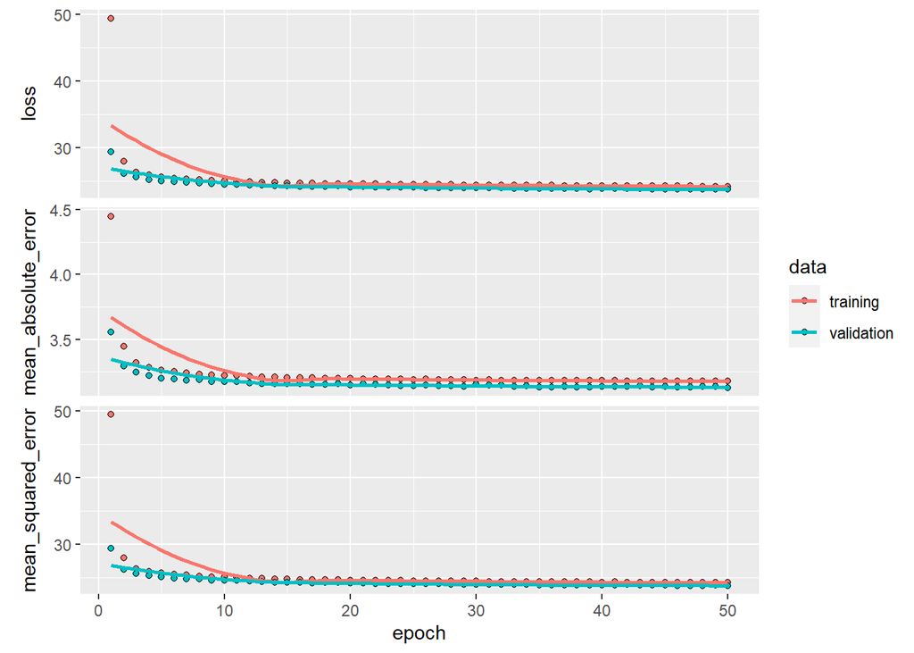

```r
# Plot training history
plot(history)
```

```r
# Get weights of the model
get_weights(model)
```

```
## [[1]]
##              [,1]         [,2]          [,3]        [,4]        [,5]
##  [1,]  0.91538215  1.082853913  0.8536532521  0.19852121  1.76151645
##  [2,] -0.34759328  0.492673963 -1.0112047195 -0.43800974  0.29415950
##  [3,]  1.01371968  0.309880674  0.0982642174  0.19393286  0.12798588
##  [4,] -0.35276595  0.081416592 -0.9222195745 -0.28786981  0.36541885
##  [5,] -0.16917704  0.265720636  0.3724296391  0.05829550  0.17607956
##  [6,]  0.53285480  0.355514109  0.0331851356  0.07024603  0.37864122
##  [7,] -0.23713462  0.125525668  0.1634881496 -0.19160776  0.04696672
##  [8,] -1.28259611  0.112844989 -0.1960742921 -2.01526642  0.13913171
##  [9,]  0.04481915  0.002108886 -1.5778481960 -0.01974691  0.48279986
## [10,]  0.08411817  0.015598579 -0.2510998249 -0.57194513 -0.03939239
## [11,] -0.35840473 -0.098407924  0.2801516354  0.41162577  0.38210434
## [12,] -0.53798467 -0.157880202  0.0001383213  0.24151275 -0.13684763
## [13,] -0.47959146  0.053974904  0.0103198206 -0.04074258  0.02283492
```

[output cut: 82 more lines]

Check tensorboard view here: http://localhost:6006/

Now we can build a sequential model with keras. Define a model with 1 hidden layer with 20 units, and 1 output unit, for the target variable. Remember to specify a non-linear activation such as `Tanh` or `ReLU` for the hidden layer, and a linear activation function for the output unit (as it is a regression task!). If we don’t specify a non-linear activation we will just be training a linear mapping and we have seen that there are no benefits of stacking layers.

When compiling the model take care to use appropriate optimizer, loss and evaluation metric. Use mean squared error as the loss, and mean absolute error and mean squared errors as the evaluation metric (pass them as a `list()`). There are some optimisers that can be used out of the box, among those, standard one are vanilla SGD `optimizer_sgd()` or ADAM `optimizer_adam()`. In our applications, as networks are small and relatively shallow, we are fine with those. Use `ADAM` just to be on the fast side of things. [Some more info here, for instance](https://medium.com/geekculture/a-2021-guide-to-improving-cnns-optimizers-adam-vs-sgd-495848ac6008) or similar, just google it.

*Side Note*: Since our model is not very deep in this application, we can use most of the nonlinearities successfully. In practice, when we train deep neural networks (with a large number of hidden layers) we prefer to use ReLU or similar non-saturating functions as the activation function, as it does not suffer from the problem of Vanishing or Exploding gradients. The gradient of those functions becomes infinitesimally small for very large or very small values, which could generate issues. In a network of $L$ hidden layers, $L$ derivatives will be multiplied together. If the derivatives are large then the gradient will increase exponentially as we propagate down the model until they eventually explode, and this is what we call the problem of exploding gradient. Alternatively, if the derivatives are small then the gradient will decrease exponentially as we propagate through the model until it eventually vanishes, and this is the vanishing gradient problem.

How many training parameters are needed? Can you account for the total number of parameters at each layer? The network needs 341 parameters. These are split as Layer 1: 320 parameters – (20x15) weight and (20x1) bias matrix, and Layer 2: 21 parameters – (20x1) weight matrix and (1x1) bias unit.

Fit the model and store the `fit()` output into a training history. Use a reasonable batch_size, epochs, and pass validation data as a `list(val_data, val_target)`. The validation data is only used to evaluate the loss and evaluation metric at the end of each epoch. The model will run in _ evaluation_ or *inference* mode on these datapoints and will never participate in optimizing model *parameters*. Besides checking the final model accuracy for a given set of hyperparametes to be chosen, this is useful for stopping training after a certain number of epochs if we see the validation error increasing with training. We can also program the model to do so, this is called Early Stopping. This can be done by using a training callback for early stopping: `callback_early_stopping()`, where we can pass the argument `patience=C` to stop training if there is no improvement after $C$ epochs.

More info on `callbacks`: https://keras.rstudio.com/articles/training_callbacks.html More info on `fit` function: https://keras.rstudio.com/reference/fit.html

Now that the model training is complete we can look at the history, as provided by keras. Just `plot(history)` to plot it. Also, look at our trained weights. Pay attention to the trained weight matrices and try to recognize the transformation weights and the bias units.

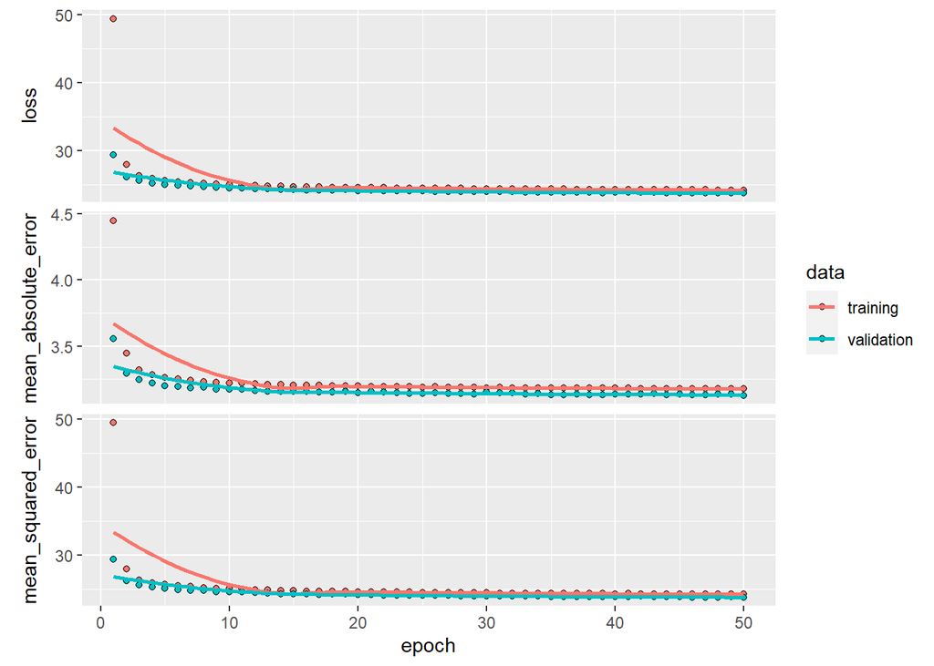

```r
plot(history)
```

```r
# Get weights of model
get_weights(model)
```

```
## [[1]]
##              [,1]         [,2]          [,3]        [,4]        [,5]
##  [1,]  0.91538215  1.082853913  0.8536532521  0.19852121  1.76151645
##  [2,] -0.34759328  0.492673963 -1.0112047195 -0.43800974  0.29415950
##  [3,]  1.01371968  0.309880674  0.0982642174  0.19393286  0.12798588
##  [4,] -0.35276595  0.081416592 -0.9222195745 -0.28786981  0.36541885
##  [5,] -0.16917704  0.265720636  0.3724296391  0.05829550  0.17607956
##  [6,]  0.53285480  0.355514109  0.0331851356  0.07024603  0.37864122
##  [7,] -0.23713462  0.125525668  0.1634881496 -0.19160776  0.04696672
##  [8,] -1.28259611  0.112844989 -0.1960742921 -2.01526642  0.13913171
##  [9,]  0.04481915  0.002108886 -1.5778481960 -0.01974691  0.48279986
## [10,]  0.08411817  0.015598579 -0.2510998249 -0.57194513 -0.03939239
## [11,] -0.35840473 -0.098407924  0.2801516354  0.41162577  0.38210434
## [12,] -0.53798467 -0.157880202  0.0001383213  0.24151275 -0.13684763
## [13,] -0.47959146  0.053974904  0.0103198206 -0.04074258  0.02283492
```

[output cut: 82 more lines]

Now we can evaluate our model predictions on the held-out testing set, and compare it to the validation set to see if we are close (ballpark) so we can see if the val set is a good proxy for it. So that we do not need to compute the test score at every step, but keep in mind that it should be done!

```r
# make predictions and evaluate using validation set
# Evaluate using validation set
eval_result_val <- model %>% evaluate(val_data_matrix, val_target)
```

```
## 729/729 - 1s - loss: 23.7628 - mean_absolute_error: 3.1288 - mean_squared_error: 23.7628 - 779ms/epoch - 1ms/step
```

```r
print("Validation Set Evaluation:")
```

```
## [1] "Validation Set Evaluation:"
```

```r
print(eval_result_val)
```

```
##                loss mean_absolute_error  mean_squared_error
##           23.762815            3.128823           23.762815
```

```r
# Evaluate using test set
eval_result_test <- model %>% evaluate(tst_data_matrix, tst_target)
```

```
## 729/729 - 1s - loss: 23.4110 - mean_absolute_error: 3.1443 - mean_squared_error: 23.4110 - 892ms/epoch - 1ms/step
```

```r
print("Test Set Evaluation:")
```

```
## [1] "Test Set Evaluation:"
```

```r
print(eval_result_test)
```

```
##                loss mean_absolute_error  mean_squared_error
##           23.411039            3.144261           23.411039
```

```r
# Plot predictions for test set
tst_data_predictions <- predict(model, tst_data_matrix)
```

```
## 729/729 - 1s - 731ms/epoch - 1ms/step
```

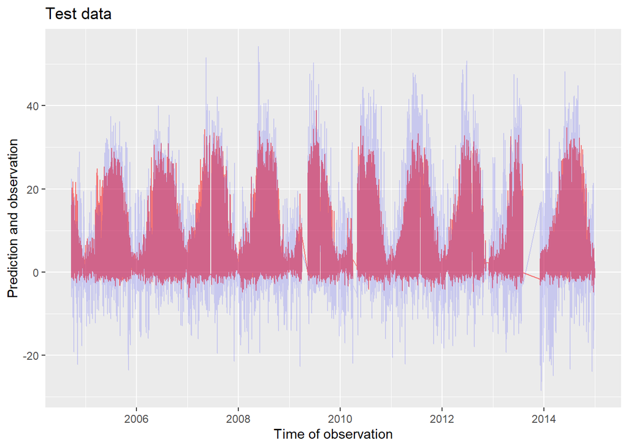

```r
plt_test <- ggplot() +
  geom_line(data = tst_data, aes(x = test_data$TIMESTAMP_START, y = tst_data_predictions), col = alpha("red", 0.5)) +
  geom_line(data = tst_data, aes(x = test_data$TIMESTAMP_START, y = tst_target), col = alpha("blue", 0.15)) +
  xlab("Time of observation") +
  ylab("Prediction and observation") +
  labs(title = "Test data")+
  theme(legend.position = "top")

print(plt_test)
```

```r
# Plot predictions for validation set
val_data_predictions <- predict(model, val_data_matrix)
```

```
## 729/729 - 1s - 669ms/epoch - 918us/step
```

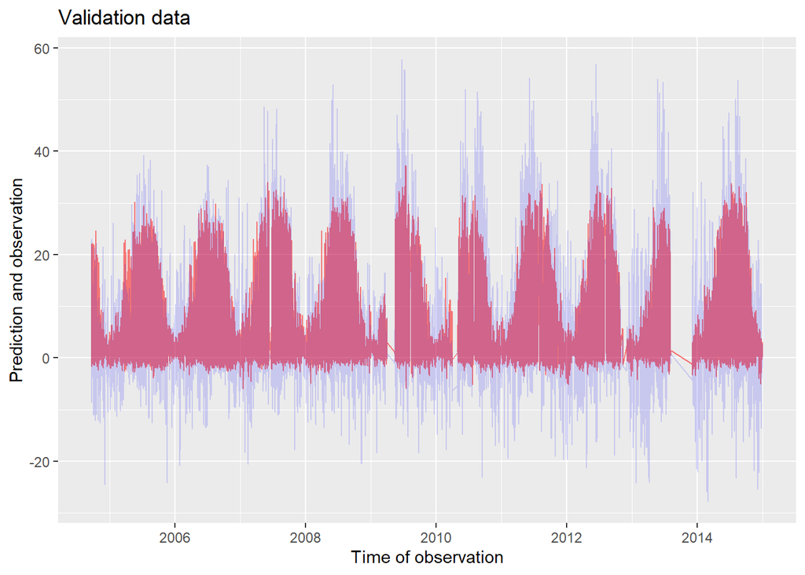

```r
plt_val <- ggplot() +
  geom_line(data = val_data, aes(x = validation_data$TIMESTAMP_START, y = val_data_predictions), col = alpha("red", 0.5)) +
  geom_line(data = val_data, aes(x = validation_data$TIMESTAMP_START, y = val_target), col = alpha("blue", 0.15)) +
  xlab("Time of observation") +
  ylab("Prediction and observation") +
  labs(title = "Validation data")+
  theme(legend.position = "top")

print(plt_val)
```

Nice! From our domain knowledge we know that the target variable `GPP_NT_VUT_REF` cannot be negative, but our dataset contains some negative observations because of noisy measurements. From the plot we see that the model learns the trends in the data, without learning the noise. Learning the noise, would go towards overfitting our data. We could even think about smoothing the data first, but this would inject bias so needs to be done very carefully,

What is the $R^2$ score (the squared Pearson’s correlation coefficient)?

```r
## compute the correlation coefficient
correlation_coefficient <- cor(tst_target, tst_data_predictions)
r_squared <- correlation_coefficient^2
r_squared
```

```
##           [,1]
## [1,] 0.6934092
```

Having done this we have an idea of how well our model generalizes against unseen data. But, to optimize the hyperparameters of the network we know for many reasons we should not use the performance on the test set to select these, that is why we use a validation set.

Write a function, that does all the above steps, and returns a trained model (contained in the `fit()` output variables).

```r
# Function name: build_model()
# Inputs: Training data, Training target, number of hidden units, activation type, number of epochs, batch size and validation size
# Output: List of 2 objects --> trained model, and the training history
## We also return the training history in case we want to make plots of the training process for each of the folds
# Function to build and train the model
k_clear_session
```

```
## function ()
## {
##     keras$backend$clear_session()
## }
## <bytecode: 0x000001a23d9312d0>
## <environment: namespace:keras>
```

```r
build_model <- function(X_trn, y_trn, X_val, y_val, num_units, activation_type, num_epochs, batch_size) {
  # Define the model
  model <- keras_model_sequential() %>%
    layer_dense(units = num_units[1], input_shape = ncol(X_trn), activation = activation_type[1]) %>%
    layer_dense(units = 1, activation = "linear")

  # Compile the model
  model %>% compile(
    optimizer = optimizer_adam(),
    loss = "mean_squared_error",
    metrics = list("mean_absolute_error", "mean_squared_error")
  )

  summary(model)
  # Set up TensorBoard callback
  tensorboard_callback <- callback_tensorboard(log_dir = "logs/fit/")

  # Fit the model
  history <- model %>% fit(
    x = X_trn,
    y = y_trn,
    epochs = num_epochs,
    batch_size = batch_size,
    validation_data = list(X_val, y_val),
    callbacks = list(
      callback_early_stopping(patience = 5),
      tensorboard_callback
    )
  )

  return(list("model" = model, "history" = history))
}
```

### Example usage:

### Set your hyperparameters

```r
# num_hidden_units <- c(20)  # Number of units in each hidden layer
# activation_types <- c("relu")  # Activation type for each hidden layer
# num_epochs <- 50
# batch_size <- 32
```

## Model selection and hyperparameters search

### 1 Layer

Here we need to write a loop that goes over a number of parameters for the number of units in the hidden layer of our model. We train the model until we are happy, and take the last value of the history for the validation means squared error. We store that in an array that we gonna inspect later.

Define a vector of `num_units` for tuning the number of hidden units, as `c(1,3,10,30,100)`. Store the validation scores in a `1 x length(num_units)` empty array `val_scores_1h`, where `_1h` indicates that we have 1 hidden layer.

```r
# Set the vector of num_units for tuning
num_units <- c(1, 3, 10, 30, 100)

# Initialize an empty array to store validation scores
val_scores_1h <- numeric(length(num_units))

# Loop over num_units and train the model
for (i in seq_along(num_units)) {
    print(paste("printing for", {i},"model"))
  # Build and train the model
  model_result <- build_model(trn_data_matrix, trn_target, val_data_matrix, val_target,
                              num_units = c(num_units[i]), activation_type = c("relu"),
                              num_epochs = 50, batch_size = 128)

  # Get the validation mean squared error from the last epoch
  val_mse <- tail(model_result$history$metrics$val_mean_squared_error, 1)

  # Store the validation score
  val_scores_1h[i] <- val_mse
}
```

```
## [1] "printing for 1 model"
## Model: "sequential_1"
## ________________________________________________________________________________
##  Layer (type)                       Output Shape                    Param #
## ================================================================================
##  dense_3 (Dense)                    (None, 1)                       16
##  dense_2 (Dense)                    (None, 1)                       2
## ================================================================================
## Total params: 18 (72.00 Byte)
## Trainable params: 18 (72.00 Byte)
## Non-trainable params: 0 (0.00 Byte)
## ________________________________________________________________________________
## 851/851 - 3s - loss: 100.1476 - mean_absolute_error: 6.1279 - mean_squared_error: 100.1476 - val_loss: 92.4820 - val_mean_absolute_error: 5.8385 - val_mean_squared_error: 92.4820 - 3s/epoch - 4ms/step
## 851/851 - 2s - loss: 90.7256 - mean_absolute_error: 5.8265 - mean_squared_error: 90.7256 - val_loss: 87.0573 - val_mean_absolute_error: 5.7341 - val_mean_squared_error: 87.0573 - 2s/epoch - 3ms/step
## 851/851 - 2s - loss: 85.7200 - mean_absolute_error: 5.7521 - mean_squared_error: 85.7200 - val_loss: 82.4055 - val_mean_absolute_error: 5.6610 - val_mean_squared_error: 82.4055 - 2s/epoch - 3ms/step
## 851/851 - 2s - loss: 80.7896 - mean_absolute_error: 5.5971 - mean_squared_error: 80.7896 - val_loss: 77.0584 - val_mean_absolute_error: 5.3929 - val_mean_squared_error: 77.0584 - 2s/epoch - 3ms/step
## 851/851 - 2s - loss: 75.1612 - mean_absolute_error: 5.2774 - mean_squared_error: 75.1612 - val_loss: 71.5657 - val_mean_absolute_error: 5.1091 - val_mean_squared_error: 71.5657 - 2s/epoch - 3ms/step
## 851/851 - 2s - loss: 70.0581 - mean_absolute_error: 5.0521 - mean_squared_error: 70.0581 - val_loss: 66.8415 - val_mean_absolute_error: 4.9247 - val_mean_squared_error: 66.8415 - 2s/epoch - 3ms/step
## 851/851 - 2s - loss: 65.5864 - mean_absolute_error: 4.8766 - mean_squared_error: 65.5864 - val_loss: 62.6720 - val_mean_absolute_error: 4.7680 - val_mean_squared_error: 62.6720 - 2s/epoch - 3ms/step
## 851/851 - 2s - loss: 61.6426 - mean_absolute_error: 4.7297 - mean_squared_error: 61.6426 - val_loss: 58.9961 - val_mean_absolute_error: 4.6254 - val_mean_squared_error: 58.9961 - 2s/epoch - 3ms/step
## 851/851 - 2s - loss: 58.1476 - mean_absolute_error: 4.6037 - mean_squared_error: 58.1476 - val_loss: 55.7214 - val_mean_absolute_error: 4.5049 - val_mean_squared_error: 55.7214 - 2s/epoch - 3ms/step
## 851/851 - 3s - loss: 55.0426 - mean_absolute_error: 4.4970 - mean_squared_error: 55.0426 - val_loss: 52.8189 - val_mean_absolute_error: 4.4020 - val_mean_squared_error: 52.8189 - 3s/epoch - 4ms/step
## 851/851 - 4s - loss: 52.2774 - mean_absolute_error: 4.4012 - mean_squared_error: 52.2774 - val_loss: 50.2360 - val_mean_absolute_error: 4.3219 - val_mean_squared_error: 50.2360 - 4s/epoch - 5ms/step
## 851/851 - 3s - loss: 49.8204 - mean_absolute_error: 4.3213 - mean_squared_error: 49.8204 - val_loss: 47.9346 - val_mean_absolute_error: 4.2426 - val_mean_squared_error: 47.9346 - 3s/epoch - 4ms/step
## 851/851 - 3s - loss: 47.6308 - mean_absolute_error: 4.2493 - mean_squared_error: 47.6308 - val_loss: 45.8822 - val_mean_absolute_error: 4.1620 - val_mean_squared_error: 45.8822 - 3s/epoch - 4ms/step
## 851/851 - 3s - loss: 45.6972 - mean_absolute_error: 4.1843 - mean_squared_error: 45.6972 - val_loss: 44.0525 - val_mean_absolute_error: 4.0990 - val_mean_squared_error: 44.0525 - 3s/epoch - 3ms/step
```

[output cut: 271 more lines]

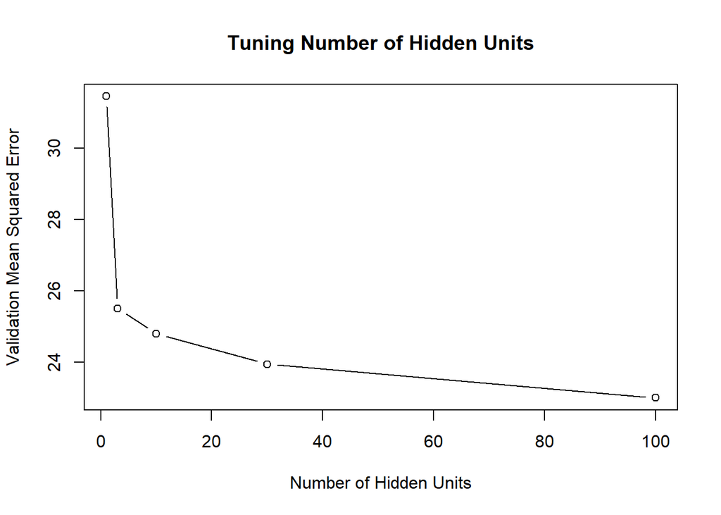

```r
# Plot the validation scores
plot(num_units, val_scores_1h, type = "b", xlab = "Number of Hidden Units",
     ylab = "Validation Mean Squared Error", main = "Tuning Number of Hidden Units")
```

```r
print(val_scores_1h)
```

```
## [1] 31.44679 25.50876 24.80704 23.95388 23.01307
```

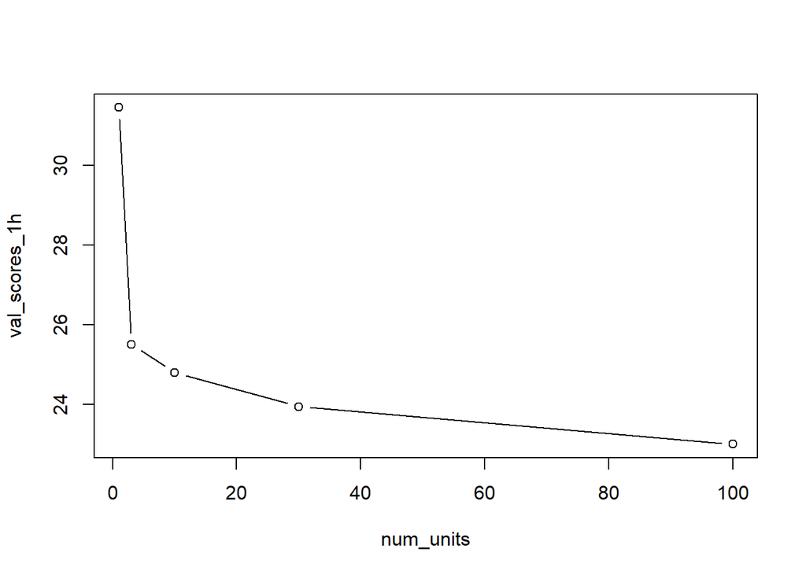

```r
num_units = c(1,3,10,30,100)
plot(num_units, val_scores_1h, type = "b")
```

```r
print(val_scores_1h)
```

```
## [1] 31.44679 25.50876 24.80704 23.95388 23.01307
```

Find the `num_units` that provides the lowest validation error.

```r
## What is the number of hidden units that gives the minimum loss ?
# Find the num_units that provides the minimum validation error
best_num_units <- num_units[which.min(val_scores_1h)]
print(paste("Best Number of Hidden Units:", best_num_units))
```

```
## [1] "Best Number of Hidden Units: 100"
```

What is the most practical number of hidden units in your opinion, for a model with 1 hidden layer? (Consider the trade-off between the reduction in MSE loss with the increase in hidden units and the increase in training / compute time and model complexity, and number of parameters to be learnt). - In terms of effeciency and generalization, I would go with 30 parameter model too. As the number of parameters increase, the possibility of “remembering” the data also increases. To avoid this, I also used early stop function where validation loss increases consistently for 5 epochs.

As one might suspect network with 100 hidden units gives the minimum loss, but it is only marginally better than a network with 30 hidden units. So, one might consider using 30 hidden units as it gives a reasonable trade-off between model complexity and the cross validation loss. Also note that if we decrease the model complexity too much, the loss on cross-validation increases significantly.

At this point, in real applications, we would merge training and validation sets, retrain the best model we found, and compute a test score. Feel free to test it out in your free time (I know, I am assuming you do not have anything better to do).

Let’s say that the layer size we just tuned, is good enough with 30 neurons. Can we do the same, but tuning a *second* hidden layer we add to our model?

Just reuse the function you wrote above, name it `build_deeper_model()`, and redo the same loop but now optimizing the number of units in the second layer.

```r
# Function name: build_model()
# Inputs: Training data, Training target, number of hidden units, activation type, number of epochs, batch size and validation size
# Output: List of 2 objects --> trained model, and the training history
## We also return the training history in case we want to make plots of the training process for each of the folds
# Function to build and train a model with two hidden layers, tuning the number of units in the second layer
k_clear_session
```

```
## function ()
## {
##     keras$backend$clear_session()
## }
## <bytecode: 0x000001a23d9312d0>
## <environment: namespace:keras>
```

```r
build_deeper_model <- function(X_trn, y_trn, X_val, y_val, num_units, activation_type, num_epochs, batch_size) {
  # Define the model
  model <- keras_model_sequential() %>%
    layer_dense(units = num_units[1], input_shape = ncol(X_trn), activation = "relu") %>%
    layer_dense(units = num_units[2], activation = "relu") %>%
    layer_dense(units = 1, activation = "linear")

  # Compile the model
  model %>% compile(
    optimizer = optimizer_adam(),
    loss = "mean_squared_error",
    metrics = list("mean_absolute_error", "mean_squared_error")
  )

  summary(model)
  # Set up TensorBoard callback
  tensorboard_callback <- callback_tensorboard(log_dir = "logs/fit/")

  # Fit the model
  history <- model %>% fit(
    x = X_trn,
    y = y_trn,
    epochs = num_epochs,
    batch_size = batch_size,
    validation_data = list(X_val, y_val),
    callbacks = list(
      callback_early_stopping(patience = 5),
      tensorboard_callback
    )
  )

  return(list("model" = model, "history" = history))
}

# Example usage for tuning the second hidden layer
num_units_2h_1f <- c(10, 30, 50)
val_scores_2h_1f <- numeric(length(num_units_2h_1f))

# Loop over num_units_2h_1f and train the model
for (i in seq_along(num_units_2h_1f)) {
  # Build and train the model
  model_result <- build_deeper_model(trn_data_matrix, trn_target, val_data_matrix, val_target,
                                      num_units = c(30, num_units_2h_1f[i]), activation_type = c("relu", "relu"),
                                      num_epochs = 50, batch_size = 128)

  # Get the validation mean squared error from the last epoch
  val_mse <- tail(model_result$history$metrics$val_mean_squared_error, 1)

  # Store the validation score
  val_scores_2h_1f[i] <- val_mse
}
```

```
## Model: "sequential_6"
## ________________________________________________________________________________
##  Layer (type)                       Output Shape                    Param #
## ================================================================================
##  dense_14 (Dense)                   (None, 30)                      480
##  dense_13 (Dense)                   (None, 10)                      310
##  dense_12 (Dense)                   (None, 1)                       11
## ================================================================================
## Total params: 801 (3.13 KB)
## Trainable params: 801 (3.13 KB)
## Non-trainable params: 0 (0.00 Byte)
## ________________________________________________________________________________
## 851/851 - 4s - loss: 37.9031 - mean_absolute_error: 3.9278 - mean_squared_error: 37.9031 - val_loss: 26.0391 - val_mean_absolute_error: 3.2941 - val_mean_squared_error: 26.0391 - 4s/epoch - 4ms/step
## 851/851 - 2s - loss: 26.1047 - mean_absolute_error: 3.3115 - mean_squared_error: 26.1047 - val_loss: 25.1252 - val_mean_absolute_error: 3.2224 - val_mean_squared_error: 25.1252 - 2s/epoch - 3ms/step
## 851/851 - 2s - loss: 25.3912 - mean_absolute_error: 3.2525 - mean_squared_error: 25.3912 - val_loss: 24.7529 - val_mean_absolute_error: 3.2002 - val_mean_squared_error: 24.7529 - 2s/epoch - 3ms/step
## 851/851 - 2s - loss: 25.0651 - mean_absolute_error: 3.2271 - mean_squared_error: 25.0651 - val_loss: 24.3899 - val_mean_absolute_error: 3.1631 - val_mean_squared_error: 24.3899 - 2s/epoch - 3ms/step
## 851/851 - 2s - loss: 24.8165 - mean_absolute_error: 3.2104 - mean_squared_error: 24.8165 - val_loss: 24.1984 - val_mean_absolute_error: 3.1404 - val_mean_squared_error: 24.1984 - 2s/epoch - 3ms/step
## 851/851 - 3s - loss: 24.6333 - mean_absolute_error: 3.1979 - mean_squared_error: 24.6333 - val_loss: 24.1658 - val_mean_absolute_error: 3.1693 - val_mean_squared_error: 24.1658 - 3s/epoch - 3ms/step
## 851/851 - 2s - loss: 24.4951 - mean_absolute_error: 3.1900 - mean_squared_error: 24.4951 - val_loss: 23.9134 - val_mean_absolute_error: 3.1306 - val_mean_squared_error: 23.9134 - 2s/epoch - 3ms/step
## 851/851 - 3s - loss: 24.3608 - mean_absolute_error: 3.1815 - mean_squared_error: 24.3608 - val_loss: 23.8783 - val_mean_absolute_error: 3.1338 - val_mean_squared_error: 23.8783 - 3s/epoch - 3ms/step
## 851/851 - 2s - loss: 24.2520 - mean_absolute_error: 3.1733 - mean_squared_error: 24.2520 - val_loss: 23.7654 - val_mean_absolute_error: 3.1181 - val_mean_squared_error: 23.7654 - 2s/epoch - 3ms/step
## 851/851 - 3s - loss: 24.1449 - mean_absolute_error: 3.1658 - mean_squared_error: 24.1449 - val_loss: 23.7038 - val_mean_absolute_error: 3.1257 - val_mean_squared_error: 23.7038 - 3s/epoch - 3ms/step
## 851/851 - 3s - loss: 24.0771 - mean_absolute_error: 3.1654 - mean_squared_error: 24.0771 - val_loss: 23.6259 - val_mean_absolute_error: 3.1119 - val_mean_squared_error: 23.6259 - 3s/epoch - 3ms/step
## 851/851 - 3s - loss: 24.0196 - mean_absolute_error: 3.1604 - mean_squared_error: 24.0196 - val_loss: 23.5175 - val_mean_absolute_error: 3.1001 - val_mean_squared_error: 23.5175 - 3s/epoch - 3ms/step
## 851/851 - 2s - loss: 23.9461 - mean_absolute_error: 3.1562 - mean_squared_error: 23.9461 - val_loss: 23.5672 - val_mean_absolute_error: 3.1177 - val_mean_squared_error: 23.5672 - 2s/epoch - 3ms/step
## 851/851 - 2s - loss: 23.8785 - mean_absolute_error: 3.1529 - mean_squared_error: 23.8785 - val_loss: 23.5916 - val_mean_absolute_error: 3.1287 - val_mean_squared_error: 23.5916 - 2s/epoch - 3ms/step
```

[output cut: 149 more lines]

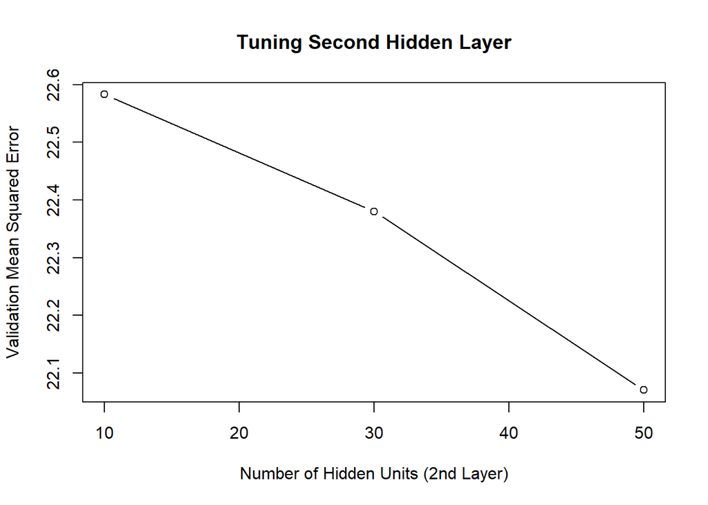

```r
# Plot the validation scores for tuning the second hidden layer
plot(num_units_2h_1f, val_scores_2h_1f, type = "b", xlab = "Number of Hidden Units (2nd Layer)",
     ylab = "Validation Mean Squared Error", main = "Tuning Second Hidden Layer")
```

Now let’s consider the given vector `num_units` for tuning the number of hidden units, in the set (10,30,50). store it in `val_scores_2h_1f` (2 hidden, 1 fixed).

What is the number of hidden units in the second layer that gives the minimum loss?

```r
# Find the num_units that provides the minimum validation error for the second hidden layer
best_num_units_2h_1f <- num_units_2h_1f[which.min(val_scores_2h_1f)]
print(paste("Best Number of Hidden Units in 2nd Layer (1 fixed):", best_num_units_2h_1f))
```

```
## [1] "Best Number of Hidden Units in 2nd Layer (1 fixed): 50"
```

So it looks again that larger is better, but at the cost of more compute / complexity.

### Jointly training two layers

```r
# Inputs: Training data, Training target, number of hidden units, activation type, number of epochs, batch size and validation size
# Output: List of 2 objects --> trained model, and the training history
## We also return the training history in case we want to make plots of the training process for each of the folds
# Function to build and train a model with two hidden layers, tuning the number of units in the second layer
k_clear_session
```

```
## function ()
## {
##     keras$backend$clear_session()
## }
## <bytecode: 0x000001a23d9312d0>
## <environment: namespace:keras>
```

```r
build_deeper_model_joint_layers  <- function(X_trn, y_trn, X_val, y_val, num_units, activation_type, num_epochs, batch_size) {
  # Define the model
  model <- keras_model_sequential() %>%
    layer_dense(units = num_units[1], input_shape = ncol(X_trn), activation = "relu") %>%
    layer_dense(units = num_units[2], activation = "relu") %>%
    layer_dense(units = 1, activation = "linear")

  # Compile the model
  model %>% compile(
    optimizer = optimizer_adam(),
    loss = "mean_squared_error",
    metrics = list("mean_absolute_error", "mean_squared_error")
  )

  summary(model)
  # Set up TensorBoard callback
  tensorboard_callback <- callback_tensorboard(log_dir = "logs/fit/")

  # Fit the model
  history <- model %>% fit(
    x = X_trn,
    y = y_trn,
    epochs = num_epochs,
    batch_size = batch_size,
    validation_data = list(X_val, y_val),
    callbacks = list(
      callback_early_stopping(patience = 5),
      tensorboard_callback
    )
  )

  return(list("model" = model, "history" = history))
}

# Example usage for tuning the second hidden layer
num_units_1h_1f <- c(30, 50, 100)
num_units_2h_1f <- c(10, 30, 50)

val_scores_2h <- numeric(length(num_units_2h_1f)**2)
combinations_list <- list()
k = 0

# Loop over num_units_2h_1f and train the model
for (i in seq_along(num_units_1h_1f)) {
  for (j in seq_along(num_units_2h_1f)){
    k = k + 1
    # Build and train the model
    print(c(num_units_1h_1f[i], num_units_2h_1f[j]))
    model_result <- build_deeper_model_joint_layers(trn_data_matrix, trn_target, val_data_matrix, val_target,
                                        num_units = c(num_units_1h_1f[i], num_units_2h_1f[j]), activation_type = c("relu", "relu"),
                                        num_epochs = 50, batch_size = 128)

    # Get the validation mean squared error from the last epoch
    val_mse <- tail(model_result$history$metrics$val_mean_squared_error, 1)

    # Store the validation score
    val_scores_2h[k] <- val_mse
    local_combi <- c(num_units_1h_1f[i], num_units_2h_1f[j])
    combinations_list <- list(combinations_list,local_combi)
  }
}
```

```
## [1] 30 10
## Model: "sequential_9"
## ________________________________________________________________________________
##  Layer (type)                       Output Shape                    Param #
## ================================================================================
##  dense_23 (Dense)                   (None, 30)                      480
##  dense_22 (Dense)                   (None, 10)                      310
##  dense_21 (Dense)                   (None, 1)                       11
## ================================================================================
## Total params: 801 (3.13 KB)
## Trainable params: 801 (3.13 KB)
## Non-trainable params: 0 (0.00 Byte)
## ________________________________________________________________________________
## 851/851 - 4s - loss: 37.6602 - mean_absolute_error: 3.8648 - mean_squared_error: 37.6602 - val_loss: 25.6935 - val_mean_absolute_error: 3.2587 - val_mean_squared_error: 25.6935 - 4s/epoch - 5ms/step
## 851/851 - 3s - loss: 25.8065 - mean_absolute_error: 3.2759 - mean_squared_error: 25.8065 - val_loss: 24.9895 - val_mean_absolute_error: 3.1973 - val_mean_squared_error: 24.9895 - 3s/epoch - 3ms/step
## 851/851 - 3s - loss: 25.3212 - mean_absolute_error: 3.2403 - mean_squared_error: 25.3212 - val_loss: 24.7761 - val_mean_absolute_error: 3.1811 - val_mean_squared_error: 24.7761 - 3s/epoch - 3ms/step
## 851/851 - 3s - loss: 25.0607 - mean_absolute_error: 3.2212 - mean_squared_error: 25.0607 - val_loss: 24.4897 - val_mean_absolute_error: 3.1710 - val_mean_squared_error: 24.4897 - 3s/epoch - 3ms/step
## 851/851 - 3s - loss: 24.8649 - mean_absolute_error: 3.2076 - mean_squared_error: 24.8649 - val_loss: 24.3228 - val_mean_absolute_error: 3.1527 - val_mean_squared_error: 24.3228 - 3s/epoch - 3ms/step
## 851/851 - 3s - loss: 24.7142 - mean_absolute_error: 3.1949 - mean_squared_error: 24.7142 - val_loss: 24.1839 - val_mean_absolute_error: 3.1407 - val_mean_squared_error: 24.1839 - 3s/epoch - 3ms/step
## 851/851 - 3s - loss: 24.5594 - mean_absolute_error: 3.1846 - mean_squared_error: 24.5594 - val_loss: 24.1548 - val_mean_absolute_error: 3.1308 - val_mean_squared_error: 24.1548 - 3s/epoch - 3ms/step
## 851/851 - 3s - loss: 24.4486 - mean_absolute_error: 3.1785 - mean_squared_error: 24.4486 - val_loss: 23.9682 - val_mean_absolute_error: 3.1285 - val_mean_squared_error: 23.9682 - 3s/epoch - 3ms/step
## 851/851 - 3s - loss: 24.3403 - mean_absolute_error: 3.1720 - mean_squared_error: 24.3403 - val_loss: 23.8732 - val_mean_absolute_error: 3.1200 - val_mean_squared_error: 23.8732 - 3s/epoch - 4ms/step
## 851/851 - 3s - loss: 24.2421 - mean_absolute_error: 3.1646 - mean_squared_error: 24.2421 - val_loss: 23.8018 - val_mean_absolute_error: 3.1100 - val_mean_squared_error: 23.8018 - 3s/epoch - 3ms/step
## 851/851 - 3s - loss: 24.1514 - mean_absolute_error: 3.1609 - mean_squared_error: 24.1514 - val_loss: 23.8157 - val_mean_absolute_error: 3.1276 - val_mean_squared_error: 23.8157 - 3s/epoch - 3ms/step
## 851/851 - 3s - loss: 24.0766 - mean_absolute_error: 3.1543 - mean_squared_error: 24.0766 - val_loss: 23.8370 - val_mean_absolute_error: 3.1144 - val_mean_squared_error: 23.8370 - 3s/epoch - 3ms/step
## 851/851 - 3s - loss: 24.0124 - mean_absolute_error: 3.1521 - mean_squared_error: 24.0124 - val_loss: 23.7354 - val_mean_absolute_error: 3.1108 - val_mean_squared_error: 23.7354 - 3s/epoch - 3ms/step
```

[output cut: 503 more lines]

```r
combinations_list
```

```
## [[1]]
## [[1]][[1]]
## [[1]][[1]][[1]]
## [[1]][[1]][[1]][[1]]
## [[1]][[1]][[1]][[1]][[1]]
## [[1]][[1]][[1]][[1]][[1]][[1]]
## [[1]][[1]][[1]][[1]][[1]][[1]][[1]]
## [[1]][[1]][[1]][[1]][[1]][[1]][[1]][[1]]
## [[1]][[1]][[1]][[1]][[1]][[1]][[1]][[1]][[1]]
## list()
##
## [[1]][[1]][[1]][[1]][[1]][[1]][[1]][[1]][[2]]
## [1] 30 10
##
##
## [[1]][[1]][[1]][[1]][[1]][[1]][[1]][[2]]
## [1] 30 30
##
##
## [[1]][[1]][[1]][[1]][[1]][[1]][[2]]
## [1] 30 50
##
##
## [[1]][[1]][[1]][[1]][[1]][[2]]
## [1] 50 10
##
##
## [[1]][[1]][[1]][[1]][[2]]
## [1] 50 30
##
##
## [[1]][[1]][[1]][[2]]
## [1] 50 50
##
##
## [[1]][[1]][[2]]
## [1] 100  10
##
##
## [[1]][[2]]
## [1] 100  30
##
##
## [[2]]
## [1] 100  50
```

```r
# Find the num_units that provides the minimum validation error for two hidden layers
val_scores_2h
```

```
## [1] 22.51917 22.16001 21.87943 22.80378 21.87126 21.52233 21.87646 21.70614
## [9] 21.24334
```

We now that larger models might be better, so let’s use something large. If the compute is just too slow, reduce this number and stick to it. Real life also means that we do not have huge compute infrastructure at hand! Store the validation scores in `val_scores_2h`. - Yes, 100,50 gives the best results i.e. about 21.2 compared to others.

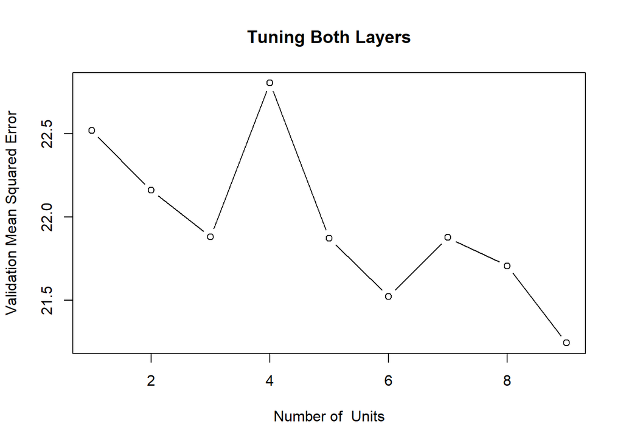

```r
# Plot the validation scores for tuning the second hidden layer
plot(x= c(1,2,3,4,5,6,7,8,9), y = val_scores_2h, type = "b", xlab = "Number of  Units",
     ylab = "Validation Mean Squared Error", main = "Tuning Both Layers")
```

We can maybe guess that at this point, the model could start overfitting. In facts, if we had to train for more than 30 epochs, we would.

### more than 2 hidden units.

Feel free to experiment with 3 to 5 layers, and see what happens. What can you extrapolate from this behavior?

```r
k_clear_session
```

```
## function ()
## {
##     keras$backend$clear_session()
## }
## <bytecode: 0x000001a23d9312d0>
## <environment: namespace:keras>
```

```r
build_even_deeper_model  <- function(X_trn, y_trn, X_val, y_val, num_epochs, batch_size) {
  # Define the model
  model <- keras_model_sequential() %>%
    layer_dense(units = 100, input_shape = ncol(X_trn), activation = "relu") %>%
    layer_dense(units = 50, activation = "relu") %>%
    layer_dense(units = 30, activation = "relu") %>%
    layer_dense(units = 15, activation = "relu") %>%
    layer_dense(units = 1, activation = "linear")

  # Compile the model
  model %>% compile(
    optimizer = optimizer_adam(),
    loss = "mean_squared_error",
    metrics = list("mean_absolute_error", "mean_squared_error")
  )

  summary(model)
  # Set up TensorBoard callback
  tensorboard_callback <- callback_tensorboard(log_dir = "logs/fit/")

  # Fit the model
  history <- model %>% fit(
    x = X_trn,
    y = y_trn,
    epochs = num_epochs,
    batch_size = batch_size,
    validation_data = list(X_val, y_val),
    callbacks = list(
      callback_early_stopping(patience = 5),
      tensorboard_callback
    )
  )

  return(list("model" = model, "history" = history))
}


print(c(num_units_1h_1f[i], num_units_2h_1f[j]))
```

```
## [1] 100  50
```

```r
model_result_4h <- build_even_deeper_model(trn_data_matrix, trn_target, val_data_matrix, val_target,
                                                num_epochs = 50, batch_size = 128)
```

```
## Model: "sequential_18"
## ________________________________________________________________________________
##  Layer (type)                       Output Shape                    Param #
## ================================================================================
##  dense_52 (Dense)                   (None, 100)                     1600
##  dense_51 (Dense)                   (None, 50)                      5050
##  dense_50 (Dense)                   (None, 30)                      1530
##  dense_49 (Dense)                   (None, 15)                      465
##  dense_48 (Dense)                   (None, 1)                       16
## ================================================================================
## Total params: 8661 (33.83 KB)
## Trainable params: 8661 (33.83 KB)
## Non-trainable params: 0 (0.00 Byte)
## ________________________________________________________________________________
## 851/851 - 4s - loss: 28.9015 - mean_absolute_error: 3.4373 - mean_squared_error: 28.9015 - val_loss: 24.2092 - val_mean_absolute_error: 3.1189 - val_mean_squared_error: 24.2092 - 4s/epoch - 5ms/step
## 851/851 - 5s - loss: 24.4073 - mean_absolute_error: 3.1685 - mean_squared_error: 24.4073 - val_loss: 23.7332 - val_mean_absolute_error: 3.1376 - val_mean_squared_error: 23.7332 - 5s/epoch - 6ms/step
## 851/851 - 4s - loss: 23.9017 - mean_absolute_error: 3.1373 - mean_squared_error: 23.9017 - val_loss: 23.2471 - val_mean_absolute_error: 3.0963 - val_mean_squared_error: 23.2471 - 4s/epoch - 5ms/step
## 851/851 - 5s - loss: 23.4683 - mean_absolute_error: 3.1109 - mean_squared_error: 23.4683 - val_loss: 22.8886 - val_mean_absolute_error: 3.0501 - val_mean_squared_error: 22.8886 - 5s/epoch - 6ms/step
## 851/851 - 5s - loss: 23.1757 - mean_absolute_error: 3.0939 - mean_squared_error: 23.1757 - val_loss: 22.9346 - val_mean_absolute_error: 3.0742 - val_mean_squared_error: 22.9346 - 5s/epoch - 6ms/step
## 851/851 - 4s - loss: 22.9202 - mean_absolute_error: 3.0755 - mean_squared_error: 22.9202 - val_loss: 22.8756 - val_mean_absolute_error: 3.0612 - val_mean_squared_error: 22.8756 - 4s/epoch - 5ms/step
## 851/851 - 3s - loss: 22.6994 - mean_absolute_error: 3.0612 - mean_squared_error: 22.6994 - val_loss: 22.3614 - val_mean_absolute_error: 3.0158 - val_mean_squared_error: 22.3614 - 3s/epoch - 4ms/step
## 851/851 - 3s - loss: 22.4216 - mean_absolute_error: 3.0450 - mean_squared_error: 22.4216 - val_loss: 22.1643 - val_mean_absolute_error: 3.0080 - val_mean_squared_error: 22.1643 - 3s/epoch - 3ms/step
## 851/851 - 4s - loss: 22.2195 - mean_absolute_error: 3.0327 - mean_squared_error: 22.2195 - val_loss: 21.8701 - val_mean_absolute_error: 3.0156 - val_mean_squared_error: 21.8701 - 4s/epoch - 4ms/step
## 851/851 - 4s - loss: 22.0289 - mean_absolute_error: 3.0230 - mean_squared_error: 22.0289 - val_loss: 21.8044 - val_mean_absolute_error: 2.9928 - val_mean_squared_error: 21.8044 - 4s/epoch - 5ms/step
## 851/851 - 4s - loss: 21.8624 - mean_absolute_error: 3.0072 - mean_squared_error: 21.8624 - val_loss: 21.7355 - val_mean_absolute_error: 2.9879 - val_mean_squared_error: 21.7355 - 4s/epoch - 4ms/step
## 851/851 - 4s - loss: 21.7071 - mean_absolute_error: 2.9998 - mean_squared_error: 21.7071 - val_loss: 21.3852 - val_mean_absolute_error: 2.9573 - val_mean_squared_error: 21.3852 - 4s/epoch - 5ms/step
## 851/851 - 3s - loss: 21.5693 - mean_absolute_error: 2.9866 - mean_squared_error: 21.5693 - val_loss: 21.4162 - val_mean_absolute_error: 2.9648 - val_mean_squared_error: 21.4162 - 3s/epoch - 4ms/step
## 851/851 - 3s - loss: 21.3764 - mean_absolute_error: 2.9786 - mean_squared_error: 21.3764 - val_loss: 21.2248 - val_mean_absolute_error: 2.9592 - val_mean_squared_error: 21.2248 - 3s/epoch - 4ms/step
## 851/851 - 3s - loss: 21.2188 - mean_absolute_error: 2.9705 - mean_squared_error: 21.2188 - val_loss: 21.1466 - val_mean_absolute_error: 2.9511 - val_mean_squared_error: 21.1466 - 3s/epoch - 3ms/step
## 851/851 - 3s - loss: 21.0871 - mean_absolute_error: 2.9591 - mean_squared_error: 21.0871 - val_loss: 21.3555 - val_mean_absolute_error: 2.9782 - val_mean_squared_error: 21.3555 - 3s/epoch - 4ms/step
## 851/851 - 3s - loss: 20.9444 - mean_absolute_error: 2.9489 - mean_squared_error: 20.9444 - val_loss: 21.4289 - val_mean_absolute_error: 2.9549 - val_mean_squared_error: 21.4289 - 3s/epoch - 4ms/step
## 851/851 - 3s - loss: 20.8727 - mean_absolute_error: 2.9469 - mean_squared_error: 20.8727 - val_loss: 21.6171 - val_mean_absolute_error: 2.9844 - val_mean_squared_error: 21.6171 - 3s/epoch - 4ms/step
```

[output cut: 17 more lines]

```r
# Get the validation mean squared error from the last epoch
val_mse_4h <- tail(model_result_4h$history$metrics$val_mean_squared_error, 1)

print(val_mse_4h)
```

```
## [1] 20.95442
```

Pull together and plot all the validation scores to guess which model was best!

```r
val_scores_1h
```

```
## [1] 31.44679 25.50876 24.80704 23.95388 23.01307
```

```r
val_scores_2h_1f
```

```
## [1] 22.58303 22.38029 22.07052
```

```r
val_scores_2h
```

```
## [1] 22.51917 22.16001 21.87943 22.80378 21.87126 21.52233 21.87646 21.70614
## [9] 21.24334
```

```r
val_mse_4h
```

```
## [1] 20.95442
```

What are your impressions on selecting models and architectures, given that little experience?

```r
# Denser models are better than simple models usually (more hidden layers are better)
# More parameters are usually better as long as they wont overfit or remember the inputs and not generalizing.
# Model selection comes more from experience and can be thought of as art rather than a science entirely.
#
```

## Conclusions

In this application we explored how we could go on to select and optimize some hyperparameters of an MLP model. We defined one independent held out validation set, in addition to a test set that we would only use to assess a final model after (usually) merging training and validation set, to provide more data for the optimization.

We have seen that in this example adding complexity to the model (layers, neurons) often means obtaining a more accurate validation set. Can someone guess why this is the case, for this dataset? What could we have done differently?

## Further explorations.

There remain so many different things to explore! For anyone interested in MLPs and neural networks, here is a list of further experiments to explore more aspects, which in principle require little modifications from the code above! I will be also happy to discuss some of these in person if there is interest. - Tune learning rates and different nonlinearities - Explore different architectures - Split data in time and not at random - Optimize other metrics - Develop a classification problem, eg by thresholding the `GPP` values into different classes, and use same architectures but using cross-entropy loss. - Push one architecture to the extreme: it is a common thing (usually, first thing to do!) to have some model, without regularization, to perfectly fit the training set. This is a bit worrysome in some settings, but the smallest architecture perfectly fitting the data could be a starting point from which branch out model search.